# Comments for MEDB 5510, Week 09

## Three types of validity

- Internal validity
  - “The extent to which we can infer that the independent variable caused the dependent variable.”
- External validity
  - “The extent to which the findings will generalize to other populations, settings, measures, and treatments.”
- Measurement validity
  - “The quality of accuracy of individual measures or scores. The extent to which a score measures what it was intended to measure.”
  - Also measurement reliability

## Internal Validity

- “The extent to which we can infer that the independent variable *caused* the dependent variable.”
- Three criteria for causality
  - IV *must precede* the outcome variable
  - IV *must be related* to the outcome
  - There must be no other variables that could explain why the IV is related to the outcome

## Establishing internal validity by the research approach

- Hierachy
  - Randomized Experiments
  - Quasi-Experimental studies
  - Comparative
  - Associational
  - Descriptive

## Internal Validity is equivalence and control

- Evaluating the internal validity of a study –
  - Equivalence of the groups on participant characteristics
  - Control of extraneous experiences and environmental variables

## Establishing equivalence

- Are groups equivalent prior to introduction of IV?
  - Assured without further work in randomized studies
  - Empirical comparisons for non-randomized studies
  - Can you use matching or statistical adjustments?

## Establishing control

- Extraneous and environmental variables
  - Not of direct interest
  - Influence the outcome
  - Imbalanced
- Example: contamination
- Is one group affected more than the other?
  - Less of an issue for laboratory studies

## Other threats to internal validity

- Regression to the mean
- Dropouts/attrition
- Bias in assignment
- Carryover effects
- Changes in environment
- Instrument or observer inconsistency
- Patient expectations
- Observer bias

## Break #1

- What you have learned
  - Internal validity
- What’s coming next
  - External validity

## External Validity

- Population external validity
  - Representative sample
  - Few or no restrictions
  - Few or no dropouts
- Ecological external validity
  - Naturalness
    - Setting
    - Procedures

## Distinction between internal and external validity

- Sampling process influences external validity
  - Random samples versus non-random samples
- Treatment allocation influences internal validity
  - Randomized design versus non-randomized design

## Trade-offs between internal and external validity

- High degree of control
  - Avoid issues of equivalence
  - Unnatural setting
- Low degree of control
  - More chances of contamination
  - Closer to how medicine is practiced.

## Break #2

- What you have learned
  - External validity
- What’s coming next
  - Measurement validity

## Break #2

- What have you learned
  - External validity
- What’s coming next
  - Measurement validity

## Measurement quotes (1 of 2)

- “The government is extremely fond of amassing great quantities of statistics. These are raised to the Nth degree, the cube roots are extracted, and the results are arranged into elaborate and impressive displays. What must be kept ever in mind, however, is that in every case, the figures are first put down by a village watchman, and he puts down anything he damn well pleases.”
  - Sir Josiah Stamp, as quoted on [Quotetab](https://www.quotetab.com/quotes/by-josiah-stamp).

## Measurement quotes (2 of 2)

- “only scientists are arrogant enough to think that they always observe with rigorous and objective scrutiny”
  - Stephen Jay Gould, The Mismeasure of Man, page 36.

## Measurements that warrant closer scrutiny

- Patient reported outcomes
  - Participant report
- Researcher evaluations
  - Only when concerned about subjectivity
- Psychological constructs
- Composite scores

## Measurement Reliability

- Synoynms: consistency, precision, stability
- No measurement is perfectly reliable
- Dependent on the population
- Look for prior efforts in reliability

## Measurement Validity

- Reliability by itself is not enough.
  - Consistent measures of the “wrong thing” is bad
- Examples of the wrong thing
  - Measuring anxiety instead of stress
  - Measuring transient changes in a patient’s mood rather than chronic depression
- Validity
  - “Degree to which a measure … measures that which it was intended to measure”
- Reliability is a pre-requisite for validity
- Validity is a journey and not a destination

## Break #3

- What you have learned
  - Measurement validity
- What’s coming next
  - Five case studies

## Break #3

- What have you learned
  - General concepts of measurement reliability/validity
- What’s next
  - Five case studies

## Case study #1 - Neighborhood Environment Survey

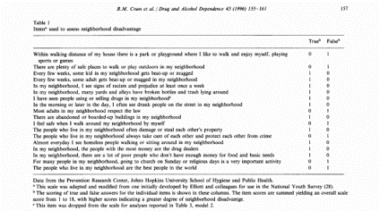

## Case study #1 - Neighborhod Environment Survey

[figure not shown]

## Case study #2 - Pain scale

[figure not shown]

## Case study #3 - Apgar score

[figure not shown]

## Case study #4 - Boston Bowel Prep Score

[figure not shown]

## Case study #4 - Boston Bowel Prep Score

[figure not shown]

Excerpt from Lai et al article

## Case study #5 - Disgust Scale Revised

[figure not shown]

## Case study #5 - Disgust scale revised

[figure not shown]

## Break #4

- What you have learned
  - Five case studies
- What’s coming next
  - Three dichotomies of measurement

## Break #4

- What you’ve seen so far
  - Five case studies
- What is coming next
  - Three dichotomies of measurement

## First dichotomy: Who is the measurer?

- Self reported outcomes
  - Also know as patient reported outcomes
- Researcher evaluations
  - Only when concerned about subjectivity

## Second dichotomy: How many pieces?

- Composite scores
  - Sum or average
- Single measurement

## Third dichotomy: is the measure soft or hard?

- Psychological or social constructs
  - Created and accepted by you and me
  - Impossible to observe directly
  - Examples: stress, anxiety

## Third dichotomy: is the measure hard or soft

- Biological or physical measure
  - Has an objective reality
  - Potential for direct observation
  - Example: obesity, dementia

## Break #5

- What you have learned
  - Three dichotomies of measurement
- What’s coming next
  - Dichotomy examples

## Break #5

- What have you learned
  - Dichotomies of measurement
- What’s coming next
  - Dichotomy examples

## Examples of self reported outcomes

Neighborhood Environment Survey

[figure not shown]

Pain scale

## Examples of researcher evaluation

[figure not shown]

Apgar score

[figure not shown]

Boston Bowel Prep Score

## Examples of composite scores

Neighborhood Environment Survey

[figure not shown]

Apgar score

## Examples of single measurements

[figure not shown]

Pain scale

[figure not shown]

Boston Bowel Prep Score

## Examples of constructs

[figure not shown]

Apgar score

Neighborhood Environment Survey

## Examples of biological or physical measurements

[figure not shown]

Boston Bowel Prep Score

[figure not shown]

## Pop quiz

[figure not shown]

- Is the disgust score
  - a self report or
  - a researcher evaluation?
- Is the disgust score
  - a composite measure or
  - a single measurement?
- Is the disgust score
  - a psychological or social construct or
  - a biological or physical measurement?

## Break #6

- What have you learned
  - Dichotomy examples
- What is coming next
  - Parallel forms
  - Split half reliability

## Measurement Reliability

- Synoynms: consistency, precision, stability
- Classical test theory
  - Observed value = True value + Measurement error
  - This is a purely hypothetical model
- Reliability coefficient
  - Variance of true values / Variance of measured values
- Depends on your population

## Measurement Reliability

- No measurement is perfectly reliable
  - Strive for 0.7 or higher in research
  - 0.6 is “borderline”.
  - Might require 0.9 or higher for individual decisions

## Indirect measures of the reliability coefficient

- Test-retest
- Interrater
- Internal consistency

## Parallel forms

- “No man ever steps in the same river twice, for it’s not the same river and he’s not the same man.”
  - Heraclitus
- Used when you can’t run the same measurement twice.
- How to develop parallel forms
  - Change the question order
  - Minor changes to the wording
- Difficult to develop two parallel forms of the same measurement.

## Split half reliability

- Only used for composite measurements
- Split into halves, correlated
  - Odd-even split
  - Random split
- Brown-Spearman adjustment

## Break #7

- What have you learned
  - Parallel forms
  - Split half reliability
- What’s next
  - KR-20
  - Cronbach’s alpha

## Kuder-Richardson 20 formula

- Only for composite measures with binary items
- Book’s formula is confusing
  - $S^2$ and $\sigma^2$ used interchangably
  - Subscripts are missing
- Correct formula
  - $X_i=\Sigma_i B_{ij}$
  - Where $B_{ij}$ is binary (0 or 1)
  - $KR-20=\frac{1}{I-1}\big(1-\frac{\Sigma_i \hat{p}_i\hat{q}_i}{S^2}\big)$
  - where $S^2=\Sigma_i(X_i-\bar{X})^2$,
  - $\hat{p}_j=\Sigma_i B_{ij}$,
  - $\hat{q}_j=\Sigma_i (1-B_{ij})$

## Kuder-Richardson 20 interpretation

- KR-20
  - $\frac{1}{I-1}\big(1-\frac{\Sigma_i \hat{p}_i\hat{q}_i}{S^2}\big)$
  - $\Sigma_i \hat{p}_i\hat{q}_i$ is a theoretical minimum variation
  - $S^2$ is observed variation
  - $S^2 = \Sigma_i \hat{p}_i\hat{q}_i$ implies randomness
  - $S^2 > \Sigma_i \hat{p}_i\hat{q}_i$ implies internal consistency

## Cronbach’s alpha, formula

- Used for composite measurements with continuous items
- Book’s formula is confusing
  - $\Sigma S^2$ should be $\Sigma S_i^2$
- Correct formula
  - $X_i=\Sigma_j X_{ij}$
  - $\alpha=\frac{1}{I-1}\Big(1-\frac{\Sigma_i S_i^2}{S^2}\Big)$
  - where $S_i^2=\Sigma_j(X_{ij}-\bar{X}_j)^2$, and
  - $S^2=\Sigma_i(X_i-\bar{X})^2$, and

## Cronbach’s alpha, interpretation

- Cronbach’s $\alpha$
  - $\frac{1}{I-1}\Big(1-\frac{\Sigma_i S_i^2}{S^2}\Big)$
  - $\Sigma_i S_i^2$ is a theoretical minimum variation
  - $S^2$ is observed variation
  - $S^2 = \Sigma_i S_i^2$ implies randomness
  - $S^2 > \Sigma_i S_i^2$ implies internal consistency
- Cronbach’s alpha is NOT a measure of unidimensionality

## Break #8

- What have you learned so far.
  - KR-20
  - Cronbach’s alpha
- What is coming next
  - Test-retest reliability
  - Inter-rater reliability

## Test-retest reliability

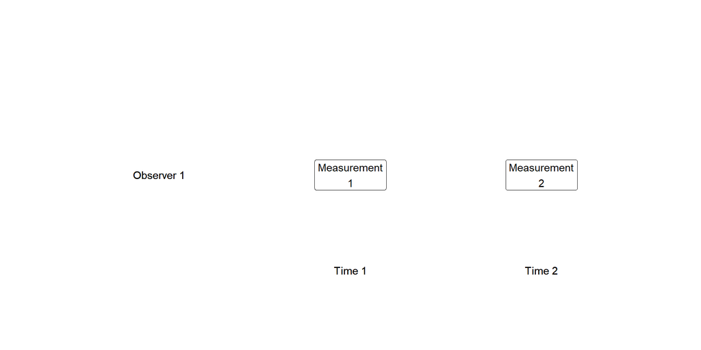

## Test-retest reliability (also called repeatability)

- Correlation of two measurements separated by time
- Length of time interval is critical
  - No carry-over
  - No changes in the true score
- Useful for composite scores and single values
- Useful for self-report and researcher evaluation
- Not possible for some measures

## Inter-rater reliability

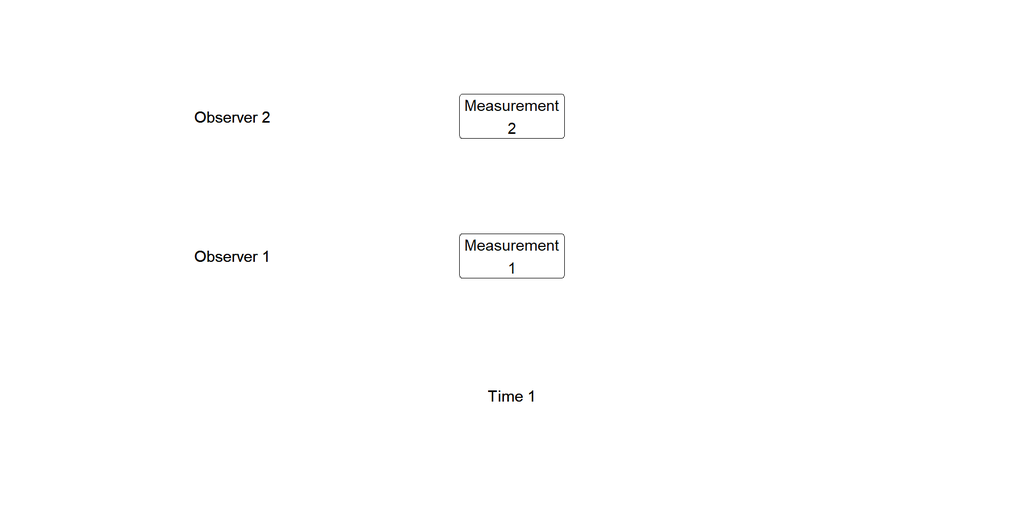

## Inter-rater reliability

- Used for researcher evaluations only
- Simplest case
  - Two independent raters
  - Ratings for every patient
- Analysis
  - Intraclass correlation or Cohen’s Kappa
- Extensions

## Practical guidance on reliability

- Is there previous literature?
  - Report their reliability coefficients
- Is your setting similar?
  - Different demographics?
  - Different cultural norms?
  - Different literacy?
  - Different language?
- Compare to reliability in your sample
  - Test-retest and inter-rater reliability preferred.
  - 0.7 or higher

## Break #9

- What have you learned so far.
  - Test-retest reliability
  - Interrater reliability
- What is coming next
  - Face validity
  - Content validity
  - Response process evidence

## Types of measurement validity

- Face validity
- Content validity
- Response process evidence
- Criterion validity
- Construct validity

## Face validity and content validity

- Face validity
  - Opinions from your patients
  - Subjective and unquantifiable
- Only used for composite measures
- Content validity
  - Opinions from outside experts
  - Subjective and unquantifiable
- Only used for composite measures

## Question.

- Should Statisticians work on problems that are subjective and unquantifiable?

## Answer.

- Yer darn tootin!

## Response process evidence

- Observe the process
  - Watch as patients fill out the form
  - Ask questions along the way
  - Monitor response times
  - Encourage them to think aloud
- Supplement with interview
- Goal is to identify problematic elements
  - Confusion, misunderstandings, language issues

## Break #10

- What have you learned so far.
  - Face validity
  - Content validity
  - Response process evidence
- What is coming next
  - Criterion validity
  - Construct validity
  - Validity of diagnostic tests

## Criterion validity

- Comparison to external criterion
  - Represents “truth”
  - Not always available
- Predictive evidence
  - Measurement in the future
  - Be careful about dropouts
- Concurrent evidence
  - Measured at the same time

## Construct validity

- Used for a psychological construct
- No direct measure of the truth exists
- Define associations consistent with your constuct
  - Does your measurement show the expected association?
  - Known as convergent evidence
- Define non-associations with your construct
  - Does your measurement also show non-association?
  - Known as discriminant or divergent evidence

## Alternative framework for validity

- Content
- Response processes
- Internal structure
- Relations to other variables
- Consequences

## Validity of diagnostic tests

- Sensitivity
  - A test’s ability to obtain a positive result when the target condition is really present
- Specificity
  - A test’s ability to obtain a negative result when the target condition is really absent

## Break #11

- What have you learned so far?
  - Criterion validity
  - Construct validity
  - Validity of diagnostic tests
- What’s next
  - Revisit the case studies

## Case study #1

## Case study #1 - Neighborhood environment survey

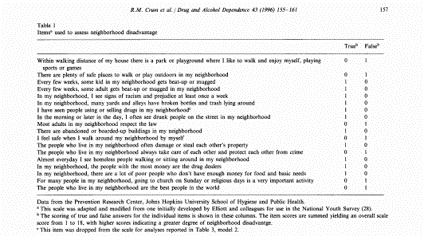

## Case study #1 - Neighborhood environment survey

- Reliability - What you can’t do
  - Inter-rater reliability
- Reliability - What you can do
  - Test-retest reliability
  - Cronbach’s alpha

## Case study #1 - Neighborhood environment survey

- Validity - What you can’t do
  - Criterion validity
- Validity - What you can do
  - Face/content validity
  - Response process validity
  - Factor analysis
  - Construct validity

## Case study #2

[figure not shown]

## Case study #2 - Pain scale

[figure not shown]

## Case study #2 - Pain scale

- Reliability - What you can’t do
  - Inter-rater reliability
  - Cronbach’s alpha
- Reliability - What you can do
  - Test-retest reliability

## Case study #2 - Pain scale

- Validity - What you can’t do
  - Criterion validity
  - Face/content validity
  - Response process validity
  - Factor analysis
- Validity - What you can do
  - Construct validity

## Case study #3

[figure not shown]

## Case study #3 - Apgar score

[figure not shown]

## Case study #3 - Apgar score

- Reliability - What you can’t do
  - Test-retest reliability
- Reliability - What you can do
  - Inter-rater reliability
  - Cronbach’s alpha

## Case study #3 - Apgar score

- Validity - What you can’t do
  - Criterion validity
- Validity - What you can do
  - Face/content validity
  - Response process validity
  - Construct validity

## Case study #4

[figure not shown]

## Case study #4 - Boston Bowel Prep Score

[figure not shown]

## Case study #4 - Boston Bowel Prep Score

- Reliability - What you can’t do
  - Test-retest reliability
  - Cronbach’s alpha
- Reliability - What you can do
  - Inter-rater reliability

## Case study #4 - Boston Bowel Prep Score

- Validity - What you can’t do
  - Face/content validity
  - Response process validity
  - Construct validity
- Validity - What you can do
  - Criterion validity

## Case study #5 - Disgust Scale Revised

[figure not shown]

## Case study #5

- What do you think?
- What measures of reliability?
  - Test-retest reliability
  - Inter-rater reliability
  - Measures of internal consistency
- What measures of validity?
  - Face/content validity
  - Response process validity
  - Criterion validity
  - Construct validity

## Conclusion

- What you’ve seen today
  - Internal validity
  - External validity
  - Measurement reliability
  - Measurement validity
  - Three dichotomies of measurement
  - Five case studies